# Práctica Parte II. Aprendizaje Estadístico

Antonio Galián Gálvez, Juan Luis Serradilla Tormos

2024-12-20

**Introducción**

En este trabajo se va a realizar un análisis de un dataset que contiene información sobre conexiones de red. El objetivo es identificar si una conexión es benigna o maligna, es decir, si es un keylogger o no. Para ello, se utilizarán distintos algoritmos de machine learning y se compararán los resultados obtenidos. El cuaderno se dividirá en las siguientes secciones:

1. Exploración del dataset y agrupación de variables
2. Preprocesamiento de los datos
3. Sampleo de los datos
4. Análisis PCA
5. Regresión logística
6. Bagging
7. Red Neuronal
8. Análisis de resultados

Antes de empezar con el trabajo tenemos que cargar las librerías necesarias, configurar el directorio de trabajo y seleccionar una semilla aleatoria para todo el cuaderno.

```r
# Seleccioamos el directorio actual como directorio de trabajo
# Si estamos compilando no lo hacemos para que no de error la compilación
if (interactive()) {
  setwd(dirname(rstudioapi::getActiveDocumentContext()$path))
}

# Cargamos las librerías necesarias
library(summarytools)
library(randomForest)
library(keras)
library(magrittr)

# Seleccionamos la semilla aleatoria para todo el cuaderno
set.seed(12345)
```

Para que el cuaderno se pueda compilar rápidamente, vamos a cargar previamente los resultados que nos hagan falta. De esta forma, podremos dejar celdas sin ejecutar pero mostrando el código.

# 1 Exploración del dataset y agrupación de variables.

En esta sección analizaremos las variables del dataset y las agruparemos por temáticas. Se describirá el significado de cada grupo de características identificado.

```r
# Leemos el dataset
mydf <- read.csv("Keylogger_Detection.csv", header = TRUE, sep = ",")

# Mostramos las variables del dataset
str(mydf)
```

```
## 'data.frame':    523617 obs. of  86 variables:
##  $ X                          : int  0 1 2 3 4 5 6 7 8 9 ...
##  $ Flow.ID                    : chr  "10.42.0.211-52.6.25.230-34451-443-6" "172.217.3.99-10.42.0.151-443-53892-6" "172.217.3.98-10.42.0.151-443-50750-6" "10.42.0.211-10.42.0.1-23025-53-17" ...
##  $ Source.IP                  : chr  "10.42.0.211" "10.42.0.151" "172.217.3.98" "10.42.0.211" ...
##  $ Source.Port                : num  34451 53892 443 23025 52602 ...
##  $ Destination.IP             : chr  "52.6.25.230" "172.217.3.99" "10.42.0.151" "10.42.0.1" ...
##  $ Destination.Port           : num  443 443 50750 53 443 ...
##  $ Protocol                   : num  6 6 6 17 6 6 6 6 6 6 ...
##  $ Timestamp                  : chr  "04/08/2017 05:12:36" "04/08/2017 07:55:51" "04/08/2017 08:48:19" "04/08/2017 05:54:10" ...
##  $ Flow.Duration              : num  12140931 418882 45 541699 7310795 ...
##  $ Total.Fwd.Packets          : num  9 102 2 1 3 2 1 5 6 1 ...
##  $ Total.Backward.Packets     : num  6 203 0 1 0 0 1 6 4 1 ...
##  $ Total.Length.of.Fwd.Packets: num  334 829 55 39 0 ...
##  $ Total.Length.of.Bwd.Packets: num  3664 279509 0 225 0 ...
##  $ Fwd.Packet.Length.Max      : num  208 517 55 39 0 0 0 748 517 0 ...
```

[output cut: 72 more lines]

# 2 Preprocesamiento de los datos.

Antes de empezar con los análisis se deben preprocesar los datos. En este sección se explicarán los preprocesamientos realizados y sus razonamientos.

Lo primero de todo es visualzar el dataset completo con todas sus variables:

```r
# Mostramos el dataset completo
dfSummary(mydf)
```

|  | No | Variable | Stats / Values | Freqs (% of Valid) | Graph | text.graph | Valid | Missing |
| --- | --- | --- | --- | --- | --- | --- | --- | --- |
| 1 | 1 | X\\\n[integer] | Mean (sd) : 261808 (151155.4)\\\nmin < med < max:\\\n0 < 261808 < 523616\\\nIQR (CV) : 261808 (0.6) | 523617 distinct values\\\n(Integer sequence) |  | : : : : : : : : : :\\\n: : : : : : : : : :\\\n: : : : : : : : : :\\\n: : : : : : : : : :\\\n: : : : : : : : : : | 523617\\\n(100.0%) | 0\\\n(0.0%) |
| 2 | 2 | Flow.ID\\\n[character] | 1\\. 8.0.6.4-8.6.0.1-0-0-0\\\n2\\. 224.0.0.251-10.42.0.1-535\\\n3\\. 10.42.0.255-10.42.0.1-861\\\n4\\. 10.42.0.255-10.42.0.1-861\\\n5\\. 255.255.255.255-0.0.0.0-6\\\n6\\. 136.142.1.3-0.95.2.3-0-0-\\\n… | \\ 4340 ( 0.8%)\\\n\\ 229 ( 0.0%)\\\n\\ 96 ( 0.0%)\\\n\\ 95 ( 0.0%)\\\n\\ 82 ( 0.0%)\\\n\\ 57 ( 0.0%)\\\n\\ 47 ( 0.0%)\\\n\\ 45 ( 0.0%)\\\n\\ 45 ( 0.0%)\\\n\\ 44 ( 0.0%)\\\n\\518537 (99.0%) |  | \\ \n \\ \n \\ \n \\ \n \\ \n \\ \n \\ \n \\ \n \\ \n \\ \nIIIIIIIIIIIIIIIIIII | 523617\\\n(100.0%) | 0\\\n(0.0%) |
| 3 | 3 | Source.IP\\\n[character] | 1\\. 10.42.0.211\\\n2\\. 10.42.0.151\\\n3\\. 10.42.0.42\\\n4\\. 8.6.0.1\\\n5\\. 10.42.0.1\\\n6\\. 202.77.129.150\\\n7\\. 64.71.142.124\\\n8\\. 172.217.12.206\\\n9\\. 192.229.173.173\\\n10\\. 172.217.3… | \\238770 (45.6%)\\\n\\134871 (25.8%)\\\n\\ 78306 (15.0%)\\\n\\ 4340 ( 0.8%)\\\n\\ 3464 ( 0.7%)\\\n\\ 1123 ( 0.2%)\\\n\\ 824 ( 0.2%)\\\n\\ 712 ( 0.1%)\\\n\\ 709 ( 0.1%)\\\n\\ 666 ( 0.1%)\\\n\\ 59832 (1… |  | IIIIIIIII \\ \nIIIII \\ \nII \\ \n \\ \n \\ \n \\ \n \\ \n \\ \n \\ \n \\ \nII | 523617\\\n(100.0%) | 0\\\n(0.0%) |
| 4 | 4 | Source.Port\\\n[numeric] | Mean (sd) : 38389.6 (18713.6)\\\nmin < med < max:\\\n0 < 43186 < 124560\\\nIQR (CV) : 18262 (0.5) | 39323 distinct values |  | \\ \\ \\ \\ \\ \\ : .\\\n\\ \\ \\ \\ \\ \\ : :\\\n. \\ \\ \\ \\ : :\\\n: \\ \\ : : :\\\n: . : : : | 523617\\\n(100.0%) | 0\\\n(0.0%) |
| 5 | 5 | Destination.IP\\\n[character] | 1\\. 10.42.0.1\\\n2\\. 10.42.0.211\\\n3\\. 10.42.0.151\\\n4\\. 10.42.0.42\\\n5\\. 192.229.173.173\\\n6\\. 8.0.6.4\\\n7\\. 180.149.136.194\\\n8\\. 104.192.110.245\\\n9\\. 239.255.255.250\\\n10\\. 172.2… | \\ 89785 (17.1%)\\\n\\ 33293 ( 6.4%)\\\n\\ 18561 ( 3.5%)\\\n\\ 12096 ( 2.3%)\\\n\\ 6032 ( 1.2%)\\\n\\ 4340 ( 0.8%)\\\n\\ 3939 ( 0.8%)\\\n\\ 3824 ( 0.7%)\\\n\\ 3522 ( 0.7%)\\\n\\ 3449 ( 0.7%)\\\n\\3447… |  | III \\ \nI \\ \n \\ \n \\ \n \\ \n \\ \n \\ \n \\ \n \\ \n \\ \nIIIIIIIIIIIII | 523617\\\n(100.0%) | 0\\\n(0.0%) |
| 6 | 6 | Destination.Port\\\n[numeric] | Mean (sd) : 6222.7 (15681.2)\\\nmin < med < max:\\\n0 < 443 < 65428\\\nIQR (CV) : 363 (2.5) | 14039 distinct values |  | :\\\n:\\\n:\\\n:\\\n: | 523617\\\n(100.0%) | 0\\\n(0.0%) |
| 7 | 7 | Protocol\\\n[numeric] | Mean (sd) : 8.4 (157.6)\\\nmin < med < max:\\\n0 < 6 < 65812\\\nIQR (CV) : 0 (18.7) | 0.00 : 4444 ( 0.8%)\\\n 0.31!: 2 ( 0.0%)\\\n 6.00 : 418771 (80.0%)\\\n 17.00 : 100397 (19.2%)\\\n65812.00 : 3 ( 0.0%)\\\n! rounded | \n\n | \\ \n \\ \nIIIIIIIIIIIIIII \\ \nIII \\ \n \\ \n \\ | 523617\\\n(100.0%) | 0\\\n(0.0%) |
| 8 | 8 | Timestamp\\\n[character] | 1\\. 05/08/2017 05:28:51\\\n2\\. 04/08/2017 09:02:50\\\n3\\. 04/08/2017 10:18:04\\\n4\\. 04/08/2017 08:01:15\\\n5\\. 04/08/2017 07:09:21\\\n6\\. 04/08/2017 07:30:30\\\n7\\. 04/08/2017 07:59:42\\\n8\\.… | \\ 258 ( 0.0%)\\\n\\ 236 ( 0.0%)\\\n\\ 231 ( 0.0%)\\\n\\ 228 ( 0.0%)\\\n\\ 226 ( 0.0%)\\\n\\ 212 ( 0.0%)\\\n\\ 211 ( 0.0%)\\\n\\ 208 ( 0.0%)\\\n\\ 205 ( 0.0%)\\\n\\ 204 ( 0.0%)\\\n\\521398 (99.6%) |  | \\ \n \\ \n \\ \n \\ \n \\ \n \\ \n \\ \n \\ \n \\ \n \\ \nIIIIIIIIIIIIIIIIIII | 523617\\\n(100.0%) | 0\\\n(0.0%) |
| 9 | 9 | Flow.Duration\\\n[numeric] | Mean (sd) : 11163067 (23071454)\\\nmin < med < max:\\\n0 < 474505 < 119996722\\\nIQR (CV) : 10277429 (2.1) | 133742 distinct values |  | :\\\n:\\\n:\\\n:\\\n: . . | 523617\\\n(100.0%) | 0\\\n(0.0%) |
| 10 | 10 | Total.Fwd.Packets\\\n[numeric] | Mean (sd) : 9.5 (97.9)\\\nmin < med < max:\\\n0 < 2 < 8671\\\nIQR (CV) : 5 (10.3) | 570 distinct values |  | :\\\n:\\\n:\\\n:\\\n: | 523617\\\n(100.0%) | 0\\\n(0.0%) |

[output cut: 76 more lines]

Ahora vamos a eliminar del dataset las variables que no aportan información relevante para el análisis.

```r
# Guardamos una copia del dataset original para comparar posteriormente
mydf.original <- mydf

# Seleccionamos los predictores que no aportan información relevante
vars.to.remove <- c("X", "Flow.ID", "Timestamp", "Source.IP", "Destination.IP", "Source.Port", "Destination.Port")

# Eliminamos los predictores seleccionados
mydf <- mydf[, !names(mydf) %in% vars.to.remove]
```

La explicación de por qué hemos eliminado cada variable es la siguiente:

- “X” es un índice que no aporta información relevante.
- “Flow.ID” es un identificador del flujo, por lo que no es una característica como tal.
- “Timestamp” es un instante temporal, no es una característica del flujo y por tanto no aporta información relevante.
- “Source.IP” y “Destination.IP” son identificadores de los dispositivos fuente y destino, respectivamente, y no son características del flujo. No aportan información al análisis. Además, no pueden interpretarse como variables ni numéricas ni categóricas (ya que tendrían demasiados valores únicos), y no se puede realizar un análisis siendo variables de tipo character.
- “Source.Port” y “Destination.Port” son los puertos de origen y destino, respectivamente, y no son características del flujo. No aportan información al análisis. No pueden interpretarse como variables categóricas (ya que tendrían demasiados valores únicos), y no dan información real de tipo numérico.

Una vez eliminamos las variables innecesarias, vamos a comprobar los valores nulos del dataset y ver cómo los tratamos. Empecemos viendo la cantidad de filas con nulos.

```r
# Buscamos las filas con valores nulos
na.coordinates <- which(is.na(mydf), arr.ind = TRUE)

# Vemos las distintas filas en las que se encuentran
na.rows <- unique(na.coordinates[, "row"])

# Calculamos la proporción respecto al número total de filas
na.prows <- length(na.rows) / nrow(mydf) * 100
paste("El porcentaje de filas con nulos es: ", na.prows, "%", sep = "")
```

```
## [1] "El porcentaje de filas con nulos es: 0.00420154425849428%"
```

Vemos que el dataset contiene muy poca cantidad de valores nulos. Por lo tanto, eliminamos las filas con valores NA.

```r
# Eliminamos las filas con valores nulos
mydf <- na.omit(mydf)
```

Ahora, eliminamos las filas duplicadas.

```r
# Eliminamos las filas duplicadas
mydf <- mydf[!duplicated(mydf), ]
```

Vamos a eliminar las columnas con desviación estándar cero. Para ello, psaremos a numérico todas las variables que no sean claramente carácteres.

```r
# Pasamos a numérico las variables que les corresponde
mydf$Packet.Length.Std <- as.numeric(mydf$Packet.Length.Std)
```

Al analizar las variables vemos que hay una con una situación particular. Esta es “CWE.Flag.Count”, que tiene valores “0” y “0.0”. Además, los valores “0.0” no son pocos, suponen el 6% del total, más que los valores “1” de otros Flags como “FIN.Flag.Count”, que solo el 1.7% son valores 1. Esto puede deberse a que por un error los valores 0.0 deberían ser 1. Si fuera un error de tipografía que pasará algunos valores 0 a 0.0 no habría tantos casos. Por lo tanto, se convertirán los valores “0.0” a “1” para que siga el formato común con los otros Flags.

```r
# Convertimos los "0.0" a 1
mydf$CWE.Flag.Count <- ifelse(mydf$CWE.Flag.Count == "0.0", "1", mydf$CWE.Flag.Count)

# Pasamos a numérico la variable
mydf$CWE.Flag.Count <- as.numeric(mydf$CWE.Flag.Count)

# Seleccionamos las columnas numéricas
num_cols <- which(sapply(mydf, is.numeric))

# Obtenemos las columnas con desviaciones estándar nulas
constant_cols <- which(sapply(mydf[, num_cols], sd) == 0)

# Eliminamos las columnas con valores constantes
mydf <- mydf[, -constant_cols]
```

Finalmente, volvemos a hacer una revisión de las variables del dataset y asignamos los tipos correspondientes a cada variable.

```r
# Pasamos los que tienen valores 0, 1 a factor.
mydf$Fwd.PSH.Flags <- as.factor(mydf$Fwd.PSH.Flags)
mydf$FIN.Flag.Count <- as.factor(mydf$FIN.Flag.Count)
mydf$SYN.Flag.Count <- as.factor(mydf$SYN.Flag.Count)
mydf$PSH.Flag.Count <- as.factor(mydf$PSH.Flag.Count)
mydf$ACK.Flag.Count <- as.factor(mydf$ACK.Flag.Count)
mydf$URG.Flag.Count <- as.factor(mydf$URG.Flag.Count)
mydf$CWE.Flag.Count <- as.factor(mydf$CWE.Flag.Count)
mydf$Class <- as.factor(mydf$Class)
```

Guardamos el dataset procesado.

```r
# Guardamos el dataset procesado
write.csv(mydf, "Keylogger_Detection_processed.csv", row.names = FALSE)
```

Para ver que el dataset procesado sirve para trabajar, vamos a comparar el porcentaje de valores positivos y negativos en los dos dasatet.

```r
# Cargamos el dataset procesado
mydf <- read.csv("Keylogger_Detection_processed.csv", header = TRUE, sep = ",")

# Pasamos las variables correspondientes a factor
mydf$Protocol <- as.factor(mydf$Protocol)
mydf$Fwd.PSH.Flags <- as.factor(mydf$Fwd.PSH.Flags)
mydf$FIN.Flag.Count <- as.factor(mydf$FIN.Flag.Count)
mydf$SYN.Flag.Count <- as.factor(mydf$SYN.Flag.Count)
mydf$PSH.Flag.Count <- as.factor(mydf$PSH.Flag.Count)
mydf$ACK.Flag.Count <- as.factor(mydf$ACK.Flag.Count)
mydf$URG.Flag.Count <- as.factor(mydf$URG.Flag.Count)
mydf$CWE.Flag.Count <- as.factor(mydf$CWE.Flag.Count)
mydf$Class <- as.factor(mydf$Class)

# Porcentaje de valores positivos y negativos en el dataset original
table(mydf.original$Class) / nrow(mydf.original) * 100
```

```
##
##    Benign Keylogger
##  58.97689  41.02311
```

```r
# Porcentaje de valores positivos y negativos en el dataset procesado
table(mydf$Class) / nrow(mydf) * 100
```

```
##
##    Benign Keylogger
##  58.90316  41.09684
```

Vemos que la proporción de casos positivos y negativos no cambia. Por lo tanto, el dataset procesado sirve para trabajar.

# 3 Sampleo de los datos.

Para poder trabajar con holgura a lo largo de la práctica vamos a coger una muestra del dataset original del 20%. De esta forma, los tiempos de ejecución serán menores y podremos trabajar más rápido. Para poder trabajar con el dataset sampleado, tendremos que conseguir que la proporción de casos positivos y negativos sea la misma que en el dataset original. Para ello, se cogerán filas aleatoriamente sin reemplazo y con una probabilidad uniforme.

```r
# Sampleamos el dataset
mydf.sample <- mydf[sample(nrow(mydf), nrow(mydf) * 0.2), ]

# Porcentaje de valores positivos y negativos en el dataset sampleado
table(mydf.sample$Class) / nrow(mydf.sample) * 100
```

```
##
##    Benign Keylogger
##  59.13903  40.86097
```

```r
# Porcentaje de valores positivos y negativos en el dataset original
table(mydf.original$Class) / nrow(mydf.original) * 100
```

```
##
##    Benign Keylogger
##  58.97689  41.02311
```

Vemos que la proporción de casos positivos y negativos en el dataset sampleado es casi idéntica a la del dataset original. Por lo tanto, el dataset sampleado sirve para trabajar. Vamos a guardar el dataset sampleado.

```r
# Guardamos el dataset sampleado
write.csv(mydf.sample, "sampled.csv", row.names = FALSE)
```

# 4 Análisis PCA.

## 4.1 Carga del dataset sampleado

Primero de todo hay que volver a cargar el dataset sampleado. Además, se deben volver a pasar a factor las variables que lo requieran.

```r
# Leemos el dataset preprocesado
mydf <- read.csv("sampled.csv", header = TRUE, sep = ",")

# Pasamos las variables correspondientes a factor
mydf$Protocol <- as.factor(mydf$Protocol)
mydf$Fwd.PSH.Flags <- as.factor(mydf$Fwd.PSH.Flags)
mydf$FIN.Flag.Count <- as.factor(mydf$FIN.Flag.Count)
mydf$SYN.Flag.Count <- as.factor(mydf$SYN.Flag.Count)
mydf$PSH.Flag.Count <- as.factor(mydf$PSH.Flag.Count)
mydf$ACK.Flag.Count <- as.factor(mydf$ACK.Flag.Count)
mydf$URG.Flag.Count <- as.factor(mydf$URG.Flag.Count)
mydf$CWE.Flag.Count <- as.factor(mydf$CWE.Flag.Count)
mydf$Class <- as.factor(mydf$Class)

# Nos aseguramos de que la clase positiva sea "Keylogger" asignando como clase de referencia a "Benign"
mydf$Class <- relevel(mydf$Class, ref = "Benign")
```

## 4.2 Análisis del PCA

Vamos a realizar el PCA con el conjunto preprocesado. Primero, seleccionamos las colunas numéricas.

```r
# Seleccionamos las columnas numéricas
mydf.numeric <- mydf[, sapply(mydf, is.numeric)]
```

Una vez tenemos las columnas numéricas seleccionadas, realizamos el PCA. No hace falta estandarizar las variales previamente ya que el PCA lo hace por nosotros con el parámetro `scale = TRUE`.

```r
# Realizamos PCA
pr.out <- prcomp(mydf.numeric, scale = TRUE)
```

Vamos a realizar un análisis del PCA para ver qué información nos aporta. Para ello, primero vamos a ver la varianza acumulada, para determinar cuáles son las componentes principales más importantes.

```r
# Vemos la varianza explicada
summary(pr.out)
```

```
## Importance of components:
##                           PC1    PC2     PC3     PC4     PC5     PC6     PC7
## Standard deviation     3.5994 2.8504 2.40787 2.01086 1.92378 1.78508 1.64527
## Proportion of Variance 0.2196 0.1377 0.09827 0.06853 0.06273 0.05401 0.04588
## Cumulative Proportion  0.2196 0.3573 0.45557 0.52411 0.58684 0.64085 0.68673
##                            PC8     PC9    PC10    PC11    PC12    PC13    PC14
## Standard deviation     1.62746 1.41877 1.31812 1.21712 1.20385 1.12681 1.00566
## Proportion of Variance 0.04489 0.03412 0.02945 0.02511 0.02456 0.02152 0.01714
## Cumulative Proportion  0.73162 0.76573 0.79518 0.82029 0.84485 0.86637 0.88352
##                           PC15    PC16   PC17    PC18    PC19    PC20    PC21
## Standard deviation     0.92250 0.88842 0.8689 0.84914 0.79130 0.72110 0.68731
## Proportion of Variance 0.01442 0.01338 0.0128 0.01222 0.01061 0.00881 0.00801
## Cumulative Proportion  0.89794 0.91132 0.9241 0.93633 0.94695 0.95576 0.96377
##                           PC22    PC23    PC24    PC25    PC26   PC27    PC28
## Standard deviation     0.63089 0.60656 0.51488 0.50058 0.42885 0.3434 0.33417
## Proportion of Variance 0.00675 0.00624 0.00449 0.00425 0.00312 0.0020 0.00189
## Cumulative Proportion  0.97051 0.97675 0.98124 0.98549 0.98861 0.9906 0.99250
##                           PC29    PC30    PC31    PC32    PC33   PC34    PC35
## Standard deviation     0.31243 0.29480 0.26320 0.20241 0.17019 0.1532 0.14939
## Proportion of Variance 0.00165 0.00147 0.00117 0.00069 0.00049 0.0004 0.00038
## Cumulative Proportion  0.99415 0.99562 0.99680 0.99749 0.99798 0.9984 0.99876
##                           PC36    PC37    PC38    PC39    PC40    PC41    PC42
## Standard deviation     0.13623 0.12425 0.11914 0.08375 0.07066 0.06629 0.04649
## Proportion of Variance 0.00031 0.00026 0.00024 0.00012 0.00008 0.00007 0.00004
## Cumulative Proportion  0.99908 0.99934 0.99958 0.99970 0.99978 0.99986 0.99989
##                           PC43    PC44    PC45    PC46    PC47    PC48    PC49
## Standard deviation     0.04564 0.03702 0.02990 0.02851 0.02389 0.01895 0.01486
## Proportion of Variance 0.00004 0.00002 0.00002 0.00001 0.00001 0.00001 0.00000
## Cumulative Proportion  0.99993 0.99995 0.99997 0.99998 0.99999 1.00000 1.00000
##                            PC50      PC51      PC52      PC53      PC54
## Standard deviation     0.008025 3.979e-05 9.703e-15 6.543e-15 4.523e-15
## Proportion of Variance 0.000000 0.000e+00 0.000e+00 0.000e+00 0.000e+00
## Cumulative Proportion  1.000000 1.000e+00 1.000e+00 1.000e+00 1.000e+00
##                             PC55      PC56      PC57      PC58      PC59
## Standard deviation     2.378e-15 9.424e-16 6.751e-16 4.821e-16 5.242e-17
## Proportion of Variance 0.000e+00 0.000e+00 0.000e+00 0.000e+00 0.000e+00
## Cumulative Proportion  1.000e+00 1.000e+00 1.000e+00 1.000e+00 1.000e+00
```

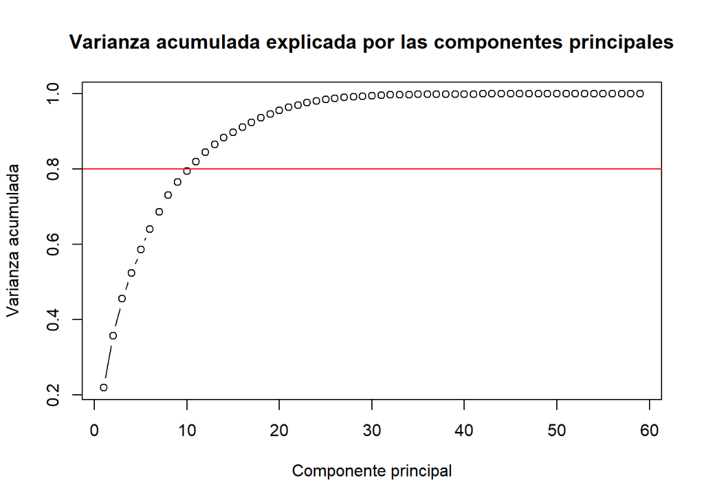

```r
# Realizamos un gráfico de la varianza acumulada
pr.out.cumvar <- cumsum(pr.out$sdev^2 / sum(pr.out$sdev^2))
plot(
  pr.out.cumvar,
  xlab = "Componente principal",
  ylab = "Varianza acumulada",
  main = "Varianza acumulada explicada por las componentes principales",
  type = "b"
)
abline(h = 0.8, col = "red")
```

```r
# Seleccionamos las componentes principales que expliquen al menos el 80% de la varianza
ncomp <- which(pr.out.cumvar > 0.8)[1]
ncomp
```

```
## [1] 11
```

Vemos que necesitamos las 11 primeras componentes principales para explicar el 80% de la varianza. Solo con las 2 primeras componentes principales explicamos tan solo el 35.73% de la varianza, una cifra muy baja. Por tanto, necesitamos muchas componentes principales para explicar la varianza de los datos.

```r
# Realizamos un biplot solo con los vectores, no con los datos
png("biplot.png")
biplot(pr.out, scale = 0, xlim = c(-15, 15), ylim = c(-15, 15))
dev.off()
```

Por todo esto, podemos ver que la elaboración de un modelo de clasificación que identifique conexiones de keystrokes va a ser un problema complicado. Tenemos muchos predictores y ver las relaciones entre ellos no va a ser una tarea sencilla. Si intentásemos reducir la dimensionalidad del problea con PCA como mucho podríamos reducir a 11 dimensiones, lo cual sigue siendo una gan cantidad de variables.